# Exercise 2, Week 2: Regression and model validation

This week, we are working with student questionaire (“learning2014” dataset), exploring the teaching and learning on introduction to statistics in social sciences course at University of Helsinki in 2014. For a detailed description about the dataset, [pleaset see the data code book](https://www.mv.helsinki.fi/home/kvehkala/JYTmooc/JYTOPKYS2-meta.txt) (in Finnish)

We will base our analysis on four original variables and three sum variables:

| Variable | Description |
| --- | --- |
| age | Age (in years) derived from the date of birth |
| attitude | Global attitude toward statistics |
| points | Exam points |
| gender | Gender: M (Male), F (Female) |
| deep | A sum variable for *deep learning* that consists of “D03”, “D11”, “D19”, “D27”, “D07”, “D14”, “D22”, “D30”,“D06”, “D15”, “D23”, and “D31” (see codebook above) |
| stra | A sum variable for *strategic learning* that consists of “SU02”,“SU10”,“SU18”,“SU26”, “SU05”,“SU13”,“SU21”,“SU29”,“SU08”,“SU16”,“SU24”, and “SU32” (see codebook above) |
| surf | A sum variable for *surface learning* that consists of “ST01”,“ST09”,“ST17”,“ST25”,“ST04”,“ST12”,“ST20”, and “ST28” (see codebook above) |

Let us begin by reading learning data csv file – prepared earlier – as a data.frame from repo:

```r
library(tidyverse)

learning2014 <- read.table("https://raw.githubusercontent.com/tuohmas/IODS-project/master/data/learning2014.csv",
                           sep = ",", header = TRUE)
glimpse(learning2014)
```

```
## Rows: 166
## Columns: 7
## $ gender   <chr> "F", "M", "F", "M", "M", "F", "M", "F", "M", "F", "M", "F", "~
## $ age      <int> 53, 55, 49, 53, 49, 38, 50, 37, 37, 42, 37, 34, 34, 34, 35, 3~
## $ attitude <int> 37, 31, 25, 35, 37, 38, 35, 29, 38, 21, 39, 38, 24, 30, 26, 4~
## $ deep     <dbl> 3.583333, 2.916667, 3.500000, 3.500000, 3.666667, 4.750000, 3~
## $ stra     <dbl> 3.375, 2.750, 3.625, 3.125, 3.625, 3.625, 2.250, 4.000, 4.250~
## $ surf     <dbl> 2.583333, 3.166667, 2.250000, 2.250000, 2.833333, 2.416667, 1~
## $ points   <int> 25, 12, 24, 10, 22, 21, 21, 31, 24, 26, 31, 31, 23, 25, 21, 3~
```

To get a handle of our variables, we will plot attitude against exam points as a scatter plot, and use gender as an aesthetic element. Finally, let’s add a regression line layer with 95% confidence interval:

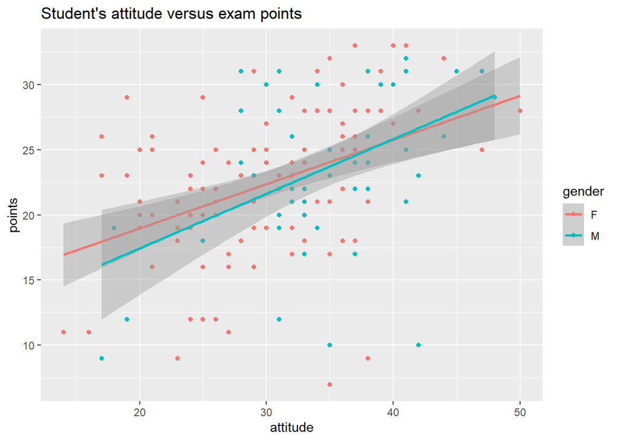

```r
library(ggplot2)

# initialize plot with data and aesthetic mapping
plot <- ggplot(learning2014, aes(x = attitude, y = points, col = gender)) +
  geom_point() +# define the visualization type (points)
  geom_smooth(method = "lm") + # add a regression line
  # add a main title and draw the plot
  ggtitle("Student's attitude versus exam points")

plot
```

As we can see, a clear positive association between attitude versus exam points exists. Let’s explore this linear relationship further with multiple regression model.

## Multiple regression model

Now we can begin to work with a regression model that would predict student exam points.

Let’s consider pearson correlations between our variables. Visually, this is neatly done with a plot matrix using a ggpairs() function, available with GGally library.

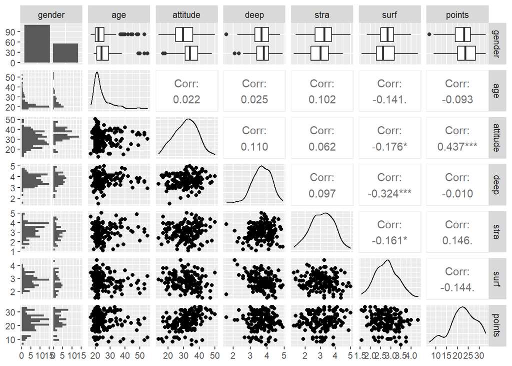

```r
library(GGally)

ggpairs(learning2014, lower = list(combo = wrap("facethist", bins = 20)))
```

We might hypothesize that we can predict points as target variables using three explanatory variables.

As the most promising candidates, let’s choose the three variables with the highest absolute correlations with points, namely

1. **attitude (var name “attitude”)**, Pearson correlation 0.437;
2. **strategic learning (stra)**, correlation 0.146; and
3. **surface learning (surf)**, correlation -0.144.

Note that, by convention, correlation sizes under 0.30 might be interpreted as negligible, casting some doubt over our second and third explanatory variables.

Now we can create a linear model that takes points attitude, stra and surf as explanatory variables. Let’s then print out a summary of the model.

```r
my_model1 <- lm(points ~ attitude + stra + surf, data = learning2014)
summary(my_model1)
```

```
##
## Call:
## lm(formula = points ~ attitude + stra + surf, data = learning2014)
##
## Residuals:
##      Min       1Q   Median       3Q      Max
## -17.1550  -3.4346   0.5156   3.6401  10.8952
##
## Coefficients:
##             Estimate Std. Error t value Pr(>|t|)
## (Intercept) 11.01711    3.68375   2.991  0.00322 **
## attitude     0.33952    0.05741   5.913 1.93e-08 ***
## stra         0.85313    0.54159   1.575  0.11716
## surf        -0.58607    0.80138  -0.731  0.46563
## ---
## Signif. codes:  0 '***' 0.001 '**' 0.01 '*' 0.05 '.' 0.1 ' ' 1
##
## Residual standard error: 5.296 on 162 degrees of freedom
## Multiple R-squared:  0.2074, Adjusted R-squared:  0.1927
## F-statistic: 14.13 on 3 and 162 DF,  p-value: 3.156e-08
```

Let’s go back and fix the model so that it only has statistically significant explanatory variables, namely the *attitude*:

```r
my_model2 <- lm(points ~ attitude, data = learning2014)
summary(my_model2)
```

```
##
## Call:
## lm(formula = points ~ attitude, data = learning2014)
##
## Residuals:
##      Min       1Q   Median       3Q      Max
## -16.9763  -3.2119   0.4339   4.1534  10.6645
##
## Coefficients:
##             Estimate Std. Error t value Pr(>|t|)
## (Intercept) 11.63715    1.83035   6.358 1.95e-09 ***
## attitude     0.35255    0.05674   6.214 4.12e-09 ***
## ---
## Signif. codes:  0 '***' 0.001 '**' 0.01 '*' 0.05 '.' 0.1 ' ' 1
##
## Residual standard error: 5.32 on 164 degrees of freedom
## Multiple R-squared:  0.1906, Adjusted R-squared:  0.1856
## F-statistic: 38.61 on 1 and 164 DF,  p-value: 4.119e-09
```

Let’s remind ourselves that we are modelling exam points with simple linear equation $y = \alpha+\beta x+\epsilon$, where

- $y$ is the target variable (points),
- $x$ is explanatory variable (attitude),
- $\beta$ quantifies the relationship between $y$ and $x$,
- $\alpha$ is a constant representig the point where regression line intersects the y axis, and
- $\epsilon$ is an unobservable random variable that estimates the error (residual) inherent in the model.

With that, let’s explain the summary table:

- Estimate of the constant parameter is positive and quite high ($\alpha = 11.63$), with very high certainty of being non-zero ($p < 1.95×10^{-9}$)
- Estimated effect of attitude is positive ($\beta=0.352$). From associated *F*-test we can determine that the beta coefficient is significantly different from zero ($p < 4.12×10^{-9}$), pointing a statistically significant relationship between $y$ and $x$.
- Based on a *F*-test, our model explains a significant amount of variance in the outcome variable, with very low risk level ($F(1, 164) = 38.61, p < 4.12×10^{-9}$)
- Multiple $R^{2}$ tells us that 19.1% of the variation in exam points can be explained by our attitude variable.

Finally, let’s explore how well our fitted model satisfies the core assumptions of linear regression model.

For this end, lets consider three diagnostic plots:

- **Residuals vs Fitted** allows us to explore the assumption that model errors are not dependent on explanatory variables.
- **Normal QQ-plot** allows us to explore the assumption that the errors of our model are normally distributed.
- **Residuals vs Leverage** allows us to explore if our data contains any observations that have exceptionally high impact on our model.

Finally, let’s produce a diagnostic plots using the plot() function: Residuals vs Fitted values, Normal QQ-plot and Residuals vs Leverage using the argument which (by passing it a vector c(1, 2, 5) corresponding to the above graphics).

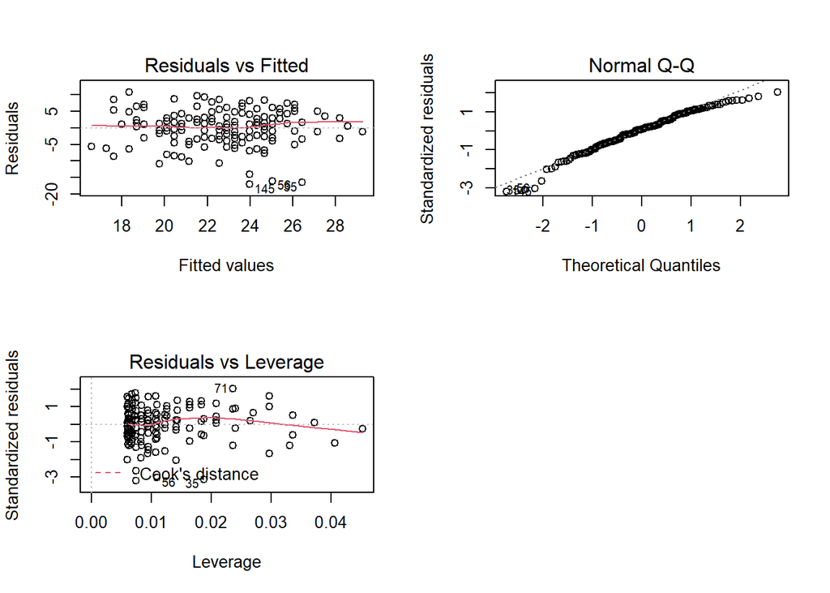

```r
# create a regression model with multiple explanatory variables
my_model2 <- lm(points ~ attitude, data = learning2014)

# draw diagnostic plots using the plot() function. Choose the plots 1, 2 and 5
par(mfrow = c(2,2))
plot(my_model2, which = c(1, 2, 5))
```